# Tree Methods Lab 2: Random Forests

Ander Wilson

## Lab overview

- Random forests with covariates regressed out prior to fitting the random forest model.

## Setup

Load the packages used in this lab.

```r
## load required libraries
#install.packages("corrplot")
library(corrplot)
#install.packages("ggplot2")
library(ggplot2)
#install.packages("tidyverse")
library(tidyverse)
#install.packages("randomForest")
library(randomForest)
```

## Load and format data

Load in the data and do some data preparation. The packages used here (`randomForests` and `BART`) can handle cateogrical predictors. We therefore do less data preparation because we do not need to make dummy variables.

```r
## read in data and only consider complete data
## this drops 327 individuals
## some tree methods handle missing data but we will not deal with that here
nhanes <- na.omit(read.csv(paste0(here::here(),"/Data/studypop.csv")))
```

```r
## our y variable - ln transformed and scaled mean telomere length
## some tree methods make assumptions about the error variance and some do not
## generally safer to transform the dependent variable to reduce heteroskedasticity
lnLTL_z <- scale(log(nhanes$TELOMEAN))
```

```r
## exposures matrix
mixture <- with(nhanes, cbind(LBX074LA, LBX099LA, LBX118LA, LBX138LA, LBX153LA, LBX170LA, LBX180LA, LBX187LA, LBX194LA, LBXHXCLA, LBXPCBLA,
                              LBXD03LA, LBXD05LA, LBXD07LA,
                              LBXF03LA, LBXF04LA, LBXF05LA, LBXF08LA))
# Most tree models are invariant the transformations of the predictors (they don't make a difference)
# here we transform it to make the plots consistent with other methods so they can be compared
mixture   <- apply(mixture, 2, log)
mixture <- scale(mixture)
colnames(mixture) <- c(paste0("PCB",c(74, 99, 118, 138, 153, 170, 180, 187, 194, 169, 126)),
                           paste0("Dioxin",1:3), paste0("Furan",1:4))
exposure_names <- colnames(mixture)
```

```r
## our X matrix
covariates <- with(nhanes, cbind(age_cent, male, bmi_cat3, edu_cat, race_cat,
                                 LBXWBCSI, LBXLYPCT, LBXMOPCT,
                                 LBXNEPCT, LBXEOPCT, LBXBAPCT, ln_lbxcot))
```

## Regress out covariates

For the random forest analysis we will regress the covariates out prior to fitting the random forest model. This model can be fit by including the covariates in the random forest model instead. The BART analysis provides an example of this.

```r
# regress covariates out
lnLTL_z_residuals <- lm(lnLTL_z~covariates)$residuals
```

## Fit random forest

The key hyperparameters here are the number of trees (`mtree`) and the number of variables used in each tree (`mtry`). These hyperparameters could be selected with cross validation and/or sensitivity analyses can be used.

```r
# fit the random forest model
set.seed(1000)
fit_rf <- randomForest(y=lnLTL_z_residuals,
                       x=mixture,
                       ntree=1000,
                       mtry=6,   # number of variables used in each tree
                       importance = TRUE)  # assess mixture component importance
```

## Prediction

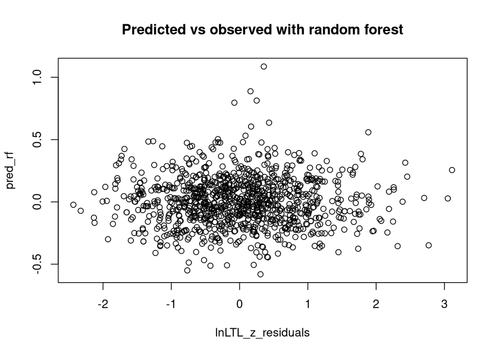

```r
pred_rf <- predict(fit_rf)

# view predicted vs observed
plot(pred_rf~lnLTL_z_residuals,
     main="Predicted vs observed with random forest")
```

## Variable importance

There are many measures of variable importance in trees and none is perfect. Two standard ones for random forests are:  
- Node Purity: how much splits on a variable improve model fit (reduce MSE for continuous outcomes) - Percent increase in MSE: a permutation approach that is normalized out of bag prediction error In both cases higher is more important.

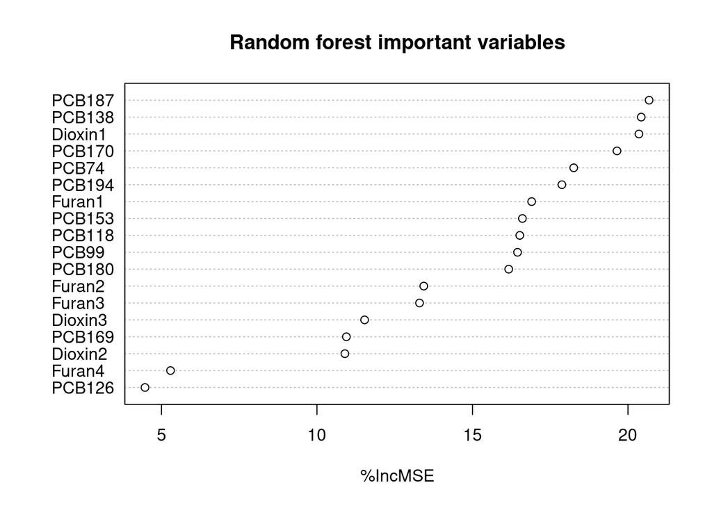

```r
varImpPlot(fit_rf, main = "Random forest important variables", type=1)
```

```r
# extract variable importance from the fit random forest model
rf_var_imortance <- importance(fit_rf)
rf_var_imortance
```

```
##           %IncMSE IncNodePurity
## PCB74   18.254812      37.58496
## PCB99   16.447896      41.36477
## PCB118  16.520690      38.55241
## PCB138  20.424975      38.69949
## PCB153  16.604403      35.26367
## PCB170  19.645892      33.77542
## PCB180  16.164813      32.25287
## PCB187  20.678796      33.16795
## PCB194  17.874428      33.56031
## PCB169  10.945167      40.32180
## PCB126   4.470413      44.79070
## Dioxin1 20.351517      43.65952
## Dioxin2 10.897060      48.25527
## Dioxin3 11.531366      44.40973
## Furan1  16.902259      48.34516
## Furan2  13.433319      38.77928
## Furan3  13.296777      39.34666
## Furan4   5.290811      48.26882
```

## Partial dependence plots

The partial dependence plot shows the main effect of one exposure averaged over values of the other exposures. In this example we are only averaging over the other mixture covariates. We are not allowing for heterogeneity based on covariates because they were regressed out prior to estimating the random forest model. Note that there is no measure of uncertainty (no confidence intervals).

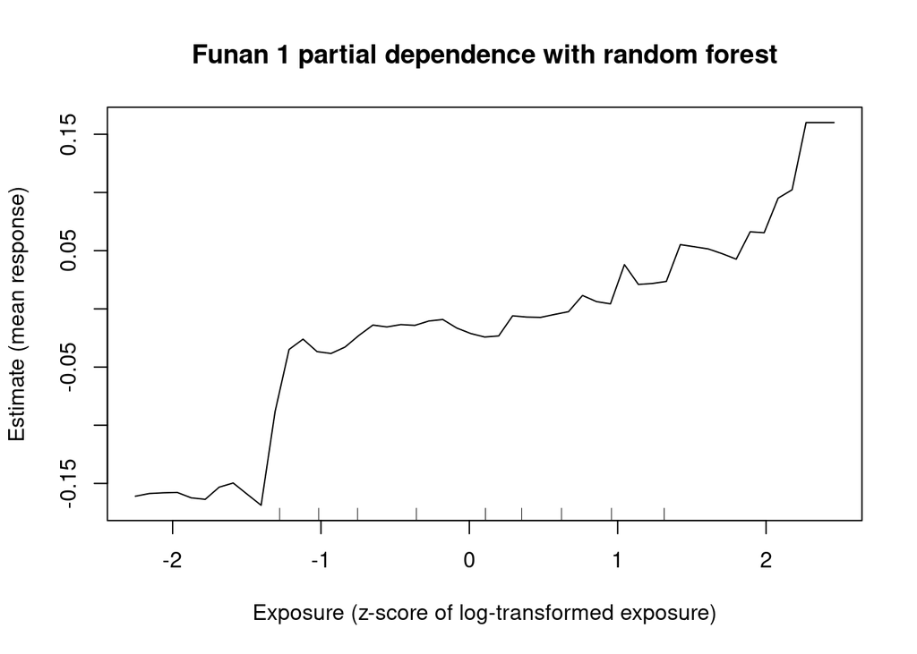

```r
partialPlot(x = fit_rf,
            pred.data = mixture,
            x.var = "Furan1",
            main = "Funan 1 partial dependence with random forest",
            xlab = "Exposure (z-score of log-transformed exposure)",
            ylab = "Estimate (mean response)")
```

See `rfutilities` package for confidence intervals for partial dependence plots with random forests.